# Plastic Pollution and its Economic Drivers

Author

Jonathan Flores Martinez, Avery Stewart, Justin Mai

# Plastic Is Everywhere

## How This Plastic Was Counted

This was a data frame with information on plastic pollution. It was originally collected by the Break Free From Plastic (BFFP) group. They are an environmental activist with an interest in reducing the amount of plastic waste in the world. They focus on reducing the use of single use plastics and other actions across the entire life cycle of plastics. They believe that the best way to address plastic pollution comes from prevention over treating the effects of pollution. The data is two years (2019 and 2020) worth of data collected through global audits that BFFP does trying to understand the sources of plastic waste creation. The information provided by the data set is the country, parent company which created the plastic waste, the number of clean up events and volunteers, and the counts of plastic waste. This was unit-less so we are assuming individual plastic pieces collected at the event. There was a grand total count and multiple columns representing the different types of plastics ranging from the thin material of bags to PVC pipe plastic. Each row represents a country and company combination. There are over 10,000 rows of data.

This data was originally found in multiple folders one each for the years 2019 and 2020. Each folder then had a separate csv file for each country. jonthegeek used map_dfr to combine all the csv files into a single data frame. This function also changed the data types. All were turned into doubles as they were numbers except for the country and parent company as these were characters. He then added a year column as the ideas was to eventually combine the two years together. After cleaning up the names with janitor he did the same thing to the 2020 data. This one had some duplicate columns so he used an if_else function to take care of that. Finally the two years were bound together and some names were changed to make it easier to work with and we now have the data set we will be using.

We also did some minor cleaning to the dataset. To address the NA values present in our data our group decided to turn any NA within the plastic type columns into a zero. The rationale being that when being filled out if there were no counts of a certain type some would input a 0 and others would leave the cell empty on a spreadsheet. To address NAs in the grand totals we summed the counts of the different type of plastics and found only two discrepancies.

## The Economic Context Behind Each Country

The second dataset was obtained through a country statistics API and provide demographic and economic indicators for the countries represented in the plastics data. In this dataset, the observational unit is the country. Variables retrieved from the API include measures such as GDP, population, population density, employment by sector, and other indicators. The documentation for the API does not clearly identify the exact reference year for every variable, so this analysis uses variables that are relatively stable across the 2019–2020 period. Data like this is collected by global organizations like the United Nations, the World’s Bank, the International Monetary Fund, and organizations like such. This data serves as numeric indicators to the state of countries. APIs like API Ninja do a good job by collecting all of this data in a single place and The data is import allowing easy access to it. This data is important to us because it provides demographic and economic context for understanding country differences in plastic collected during cleanup audits. We added it to the dataset we are working with.

## The Environmental Context Behind Each Country

The third dataset was obtained through the Global Footprint Network API by pulling country level data for 2019 and 2020 from the National Footprint and Biocapacity Accounts. The API returns environmental and development indicators for countries and territories, including metrics such as Total Biocapacity and Total Ecological Footprint. After retrieving the data, I combined the yearly responses, reshaped them into a country year format, and matched them to the plastics dataset using country and year. This allowed me to incorporate environmental context into the original dataset and compare plastic collection outcomes with a nations ecological state.

# What Are We Trying to Explain?

Plastic pollution is not only an environmental problem, but also a social and economic one. Different countries consume, regulate, and dispose of plastic in different ways, so cleanup audits can reveal both what kinds of plastics are most common and how broader characteristics of countries may shape pollution patterns. Given this, we wanted to pose two research questions that guide our analysis first.

#### Question 1: Plastic Type

Which plastic types are the most abundant in the audits, does this change from country to country?

#### Question 2: Economic Factors in Plastic Waste Generation

How do demographic and economic characteristics of countries along with their geographic characteristics associated with differences in plastic collected during cleanup audits?

# Research Question 1: Plastic Composition Across Countries

## Most Plastic Falls Into Just a Few Categories

To address the first research question, we begin by comparing the composition of plastic waste across countries and years. The following tables summarize the proportions and overall audit profiles for the five most populous countries in the dataset. These summaries help identify which plastic categories are most common and whether those patterns appear consistent across countries. Knowing how the different types of plastic play a role in the data is important because not all plastics are the same. Some are not recycable and each type of plastic have different uses.

### Table 1. Statistics of Each Plastic Type Across all Audits

```r
library(tidyverse)
library(gt)
library(httr)
library(stringr)
library(tidyjson)
library(jsonlite)
library(ggridges)
library(RColorBrewer)
library(viridis)
library(ggtext)
library(broom)
library(scales)
library(car)

plastics <- readr::read_csv('https://raw.githubusercontent.com/rfordatascience/tidytuesday/main/data/2021/2021-01-26/plastics.csv')

plastics_clean <- plastics |>
  mutate(across(empty:pvc, ~replace_na(., 0)),
         total = rowSums(across(c(empty:pvc))),
         .before = num_events)
final_merged <- readRDS("final_merged.rds")
```

```r
plastic_cols <- c("hdpe", "ldpe", "o", "pet", "pp", "ps", "pvc")

map(plastic_cols, function(col) {
  tibble(
    plastic_type = col,
    total = sum(plastics[[col]], na.rm = TRUE),
    mean = mean(plastics[[col]], na.rm = TRUE),
    median = median(plastics[[col]], na.rm = TRUE),
    sd = sd(plastics[[col]], na.rm = TRUE),
    iqr = IQR(plastics[[col]], na.rm = TRUE),
    min = min(plastics[[col]], na.rm = TRUE),
    max = max(plastics[[col]], na.rm = TRUE),
    audits_with_plastic_type = sum(plastics[[col]] > 0, na.rm = TRUE),
    percent_of_audits = mean(plastics[[col]] > 0, na.rm = TRUE)
  )
}) |>
  list_rbind() |>
  gt() |>
  fmt_percent(columns = percent_of_audits, decimals = 2) |>
  fmt_number(columns = mean:sd, decimals = 2) |>
  tab_style(
    style = cell_text(weight = "bold"),
    locations = cells_column_labels()
  ) |>
  tab_header("Summary statistics for each plastic type across all audits") |>
  cols_label(
    plastic_type = "Plastic Type",
    total = "Total",
    mean = "Mean",
    median = "Median",
    sd = "SD",
    iqr = "IQR",
    min = "Min",
    max = "Max",
    audits_with_plastic_type = "Audits With Plastic Type",
    percent_of_audits = "Percent of Audits"
  ) |>
  data_color(
    method = "numeric",
    palette = "PuBu",
    reverse = FALSE
  )
```

Table 1: Summary of Each Plastic Type Across All Audits

Summary statistics for each plastic type across all audits

| Plastic Type | Total | Mean | Median | SD | IQR | Min | Max | Audits With Plastic Type | Percent of Audits |
| --- | --- | --- | --- | --- | --- | --- | --- | --- | --- |
| hdpe | 35742 | 3.05 | 0.00 | 66.12 | 0 | 0 | 3728 | 1009 | 8.60% |
| ldpe | 116640 | 10.32 | 0.00 | 194.64 | 0 | 0 | 11700 | 1700 | 15.04% |
| o | 650583 | 49.61 | 0.00 | 1,601.99 | 2 | 0 | 120646 | 6434 | 49.07% |
| pet | 275700 | 20.94 | 0.00 | 428.16 | 0 | 0 | 36226 | 2937 | 22.31% |
| pp | 97696 | 8.22 | 0.00 | 141.81 | 0 | 0 | 6046 | 1617 | 13.61% |
| ps | 21243 | 1.86 | 0.00 | 39.74 | 0 | 0 | 2101 | 452 | 3.96% |
| pvc | 3169 | 0.35 | 0.00 | 7.89 | 0 | 0 | 622 | 194 | 2.14% |

This table shows that the “other” plastic category is the most dominant, with the highest total and appearing in nearly half of all audits. PET and LDPE are also common, while PVC and PS appear much less frequently. The zero medians and large standard deviations indicate that most audits contain little to no plastic of a given type, but a few audits contain very large amounts of plastic.

Other is a formal plastic category. Recycling centers use this category “o” to denote mixed plastics and bioplastics. Unlike other types of plastics, these plastics are not recyclable. Some of their most popular applications are multi-layered packaging and biodegrade containers often seen in restaurants. One possible reason for the strong dominance of the other category in our data would be the use of plastic as a packaging material and the use of mixed plastics that have trouble being sorted and therefore fall under the mixed plastics category that can’t be replaced.

### Table 2. Summary of Audits for the 5 Most Populated Countries

The Break Free From Plastic group annually audits the plastic waste in a county. Although it may not be a complete record of all the plastic waste it helps provide a snapshot of the plastic types and the companies that create plastic waste within a country.

```r
country_profile <- function(data, group_var1, group_var2, min_audits = 10) {
  data |>
    filter(!is.na(country), country != "EMPTY") |>
    group_by({{ group_var1 }}, {{ group_var2 }}) |>
    summarise(
      audits = n(),
      total_pieces = sum(grand_total, na.rm = TRUE),
      median_pieces = median(grand_total, na.rm = TRUE),
      mean_pieces = mean(grand_total, na.rm = TRUE),
      max_pieces = max(grand_total, na.rm = TRUE),
      .groups = "drop"
    ) |>
    filter(audits >= min_audits) |>
    arrange({{ group_var1 }}, {{ group_var2 }}) |>
    mutate(country = str_to_title(country)) |>
    filter(country %in% c("India", "China", "United States Of America",
                        "Indonesia", "Nigeria")) |>
    gt() |>
    tab_header(
      title = md(
        paste0(
          "**Table.** Plastic cleanup profile by country and year for countries
          with at least ",
           min_audits,
          " audits."
        )
      )
  ) |>
  fmt_number(
    columns = c(audits, total_pieces, median_pieces, mean_pieces, max_pieces),
    decimals = 1,
    use_seps = TRUE
  ) |>
  cols_label(
    country = md("**Country**"),
    year = md("**Year**"),
    audits = md("**Audits**"),
    total_pieces = md("**Total Pieces**"),
    median_pieces = md("**Median Pieces**"),
    mean_pieces = md("**Mean Pieces**"),
    max_pieces = md("**Max Pieces**")
  )
}


country_profile(plastics_clean, country, year, min_audits = 1)
```

**Table.** Plastic cleanup profile by country and year for countries with at least 1 audits.

| **Country** | **Year** | **Audits** | **Total Pieces** | **Median Pieces** | **Mean Pieces** | **Max Pieces** |
| --- | --- | --- | --- | --- | --- | --- |
| China | 2019 | 622.0 | 6,918.0 | 1.0 | 11.1 | 3,459.0 |
| China | 2020 | 216.0 | 2,332.0 | 1.0 | 10.8 | 207.0 |
| India | 2019 | 209.0 | 4,132.0 | 1.0 | 19.8 | 2,066.0 |
| India | 2020 | 348.0 | 16,973.0 | 3.0 | 48.8 | 4,250.0 |
| Indonesia | 2019 | 636.0 | 26,618.0 | 1.0 | 41.9 | 13,309.0 |
| Indonesia | 2020 | 294.0 | 10,156.0 | 2.0 | 34.5 | 3,710.0 |
| Nigeria | 2019 | 354.0 | 161,140.0 | 8.5 | 455.2 | 80,570.0 |
| Nigeria | 2020 | 335.0 | 63,253.0 | 4.0 | 188.8 | 30,200.0 |
| United States Of America | 2019 | 583.0 | 8,628.0 | 0.0 | 14.8 | 4,314.0 |
| United States Of America | 2020 | 376.0 | 13,994.0 | 2.0 | 37.5 | 5,299.0 |

This table shows clear differences across countries, with Nigeria having much higher total and average plastic collected per audit than others. Indonesia and India also show relatively high averages, while China and the United States have lower values despite many audits. The large gap between medians and means suggests that a small number of large cleanup events drive most of the totals.

## Visualizing Auditing Events and Plastic Types Recorded

### Figure 1. Average Plastic Waste per Audit Event

BFFP Auditing events are dependent on volunteer work. Our data set comes from 2019 and 2020. 2020 is notorious for being the height of the Covid-19 pandemic, an event that affected the entire world. Overall, the impact of auditing events in a country depend on many factors and visualizing that difference is important to our understanding of the data.

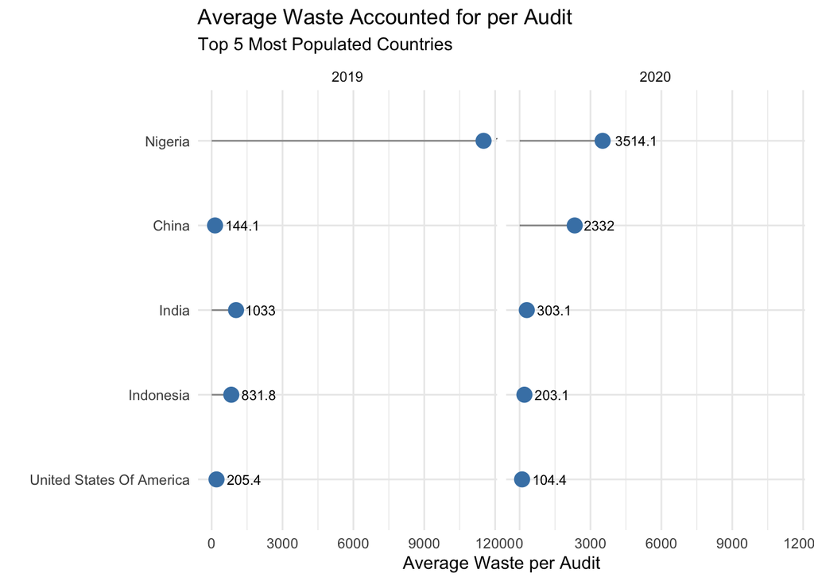

Figure 1: Average Plastic Waste per Audit for the 5 Most Populated Countries

```r
rate_ify <- function(df, numerator, denominator, name = rate){
  stopifnot(is.data.frame(df))
  df |>
    mutate({{name}} := {{numerator}}/{{denominator}})
}

plastics_clean |>
  group_by(country, year) |>
  summarise(total_trash = sum(total),
            num_events = mean(num_events),
            .groups = "drop") |>
  rate_ify(numerator = total_trash,
           denominator = num_events,
           name = avg_event_impact) |>
  mutate(country = str_to_title(country)) |>
  filter(country %in% c("India",
                        "China",
                        "United States Of America",
                        "Indonesia",
                        "Nigeria")) |>
  mutate(country = fct_reorder(country, avg_event_impact)) |>
  ggplot(aes(x = avg_event_impact, y = country)) +
  geom_segment(aes(x = 0, xend = avg_event_impact,
                   y = country, yend = country),
               color = "gray60") +
  geom_point(size = 4, color = "steelblue") +
  facet_wrap(~ year) +
  labs(
    title = "Average Waste Accounted for per Audit",
    subtitle = "Top 5 Most Populated Countries",
    x = "Average Waste per Audit",
    y = "",
    alt = "Lollipop plot of the average waste per audit for 2019 and 2020 for the 5 most populated countries, India, China, USA, Indonesia, and Nigeria."
  ) +
  geom_text(aes(label = round(avg_event_impact, 1)),
          hjust = -0.3,
          size = 3) +
  theme_minimal()
```

### Figure 2. Plastic Type Composition by Country

Another thing that may vary from country to country would be the makeup of the plastic waste that they generate.

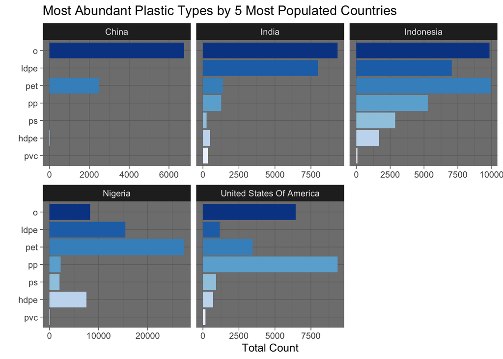

Figure 2: Most Abundant Plastic Types by 5 Most Populated Countries

```r
plastics_clean |>
  filter(country %in% c("India", "China", "United States of America",
                        "Indonesia", "Nigeria")) |>
  mutate(country = str_to_title(country)) |>
  pivot_longer(cols = c(hdpe, ldpe, o, pet, pp, ps, pvc),
               names_to = "plastic_type",
               values_to = "count") |>
  group_by(country, plastic_type) |>
  summarise(total = sum(count, na.rm = TRUE), .groups = "drop") |>
  mutate(plastic_type = fct_reorder(plastic_type, total)) |>
  ggplot(aes(x = total, y = plastic_type, fill = plastic_type)) +
  geom_col(show.legend = FALSE) +
  facet_wrap(~ country, scales = "free_x") +
  scale_fill_brewer(palette = "Blues") +
  labs(
    title = "Most Abundant Plastic Types by 5 Most Populated Countries",
    x = "Total Count",
    y = "",
    alt = "Bar graph of the amount of each plastic type found in audits from the 5 most populated countries, India, China, USA, Indonesia, and Nigeria."
  ) +
  theme_dark()
```

# Research Question 2: Economic and Geographic Patterns in Plastic Collection

## Economic Factors Don’t Tell the Whole Story

A country’s economic state and environmental state can play a role in their attitude towards the environment. Metrics like their ecological footprint and biocapacity can be used as measures of their ecological impact. This impact can vary depending on the amount of pollution a country produces, of which plastic is a type. Economic indicators like GDP, HDI, and employment sectors may also show a relationship with plastic waste generation. This can be shown more in the amount of plastic produced and how it is used. Some industry sectors may use more plastic than others, or more commodities may lead to more plastic waste.

## Comparing Plastic Waste Generation to Environmental and Economic Indicators

To address the following question we began by familiarizing ourselves with indicators, both environmental and economic. Both tables look at the 5 most populated countries for consistency through our report and because we wish to see how the largest countries deal with the issue of plastic pollution.

### Table 1. Summary of Plastics Compared to Environmental Metrics

```r
final_merged |>
  group_by(country, year) |>
  summarise(
    total_plastic = sum(total),
    avg_plastic = mean(total),
    footprint_per_capita = first(EFConsPerCap[!is.na(EFConsPerCap)]),
    biocapacity_per_capita = first(BiocapPerCap[!is.na(BiocapPerCap)]),
    hdi = first(HDI[!is.na(HDI)]),
    population = first(Population[!is.na(Population)]),
    .groups = "drop"
  ) |>
  filter_out(country == "EMPTY") |>
  filter(country %in% c("India",
                        "China",
                        "United States of America",
                        "Indonesia",
                        "Nigeria")) |>
  mutate(country = str_to_title(country)) |>
  gt() |>
  tab_header(
    title = "Country-Year Summary of Plastics and Environmental Data"
  ) |>
  cols_label(
    country = "Country",
    year = "Year",
    total_plastic = "Total Plastic Items Collected",
    avg_plastic = "Average Plastic Items Collected",
    footprint_per_capita = "Ecological Footprint per Capita",
    biocapacity_per_capita = "Biocapacity per Capita",
    hdi = "HDI",
    population = "Population"
  ) |>
  fmt_number(
    columns = c(total_plastic, avg_plastic, population),
    decimals = 0
  ) |>
  fmt_number(
    columns = c( footprint_per_capita, biocapacity_per_capita, hdi),
    decimals = 2
  )
```

Table 3: Summary of Plastic Compared to Environmental Indicators for the 5 Most Populated Countries

Country-Year Summary of Plastics and Environmental Data

[output not shown]

This table shows that countries with larger populations do not always have higher plastic totals, as Indonesia and Nigeria report much higher average plastic collected per audit than China and the United States. The United States has the highest ecological footprint and HDI but relatively moderate plastic counts, while countries with lower footprint and HDI, such as Nigeria, show much higher averages. This suggests that environmental and development indicators alone do not directly explain differences in plastic collected.

### Table 2. Summary of Plastic Waste Type Proportions Compared to Employment Sectorization

Different Industries may use plastic in different ways and therefore different types of plastics.

```r
rate_ify2 <- function(df, numerators, denominator) {
  stopifnot(is.data.frame(df))

  df |>
    mutate(across(.cols = {{ numerators }},
                  .fns = ~ .x / {{ denominator }},
                  .names = "{.col}"))
}

final_merged |>
  group_by(country) |>
  summarise(hdpe = sum(hdpe),
            ldpe = sum(ldpe),
            o = sum(o),
            pet = sum(pet),
            pp = sum(pp),
            ps = sum(ps),
            pvc = sum(pvc),
            total_waste = sum(total),
            industry = mean(employment_industry),
            service = mean(employment_services),
            ag = mean(employment_agriculture),
            .groups = "drop") |>
  filter(country %in% c("India",
                        "China",
                        "United States of America",
                        "Indonesia",
                        "Nigeria")) |>
  rate_ify2(numerator = hdpe:pvc,
           denominator = total_waste) |>

  gt() |>
  tab_header(
    title = "Proportions of Plastic Types Compared to Employment Sectorization",
    subtitle = "Data from 2019 and 2020 Featuring the 5 Most Populated Countries") |>
  fmt_percent(
    columns = hdpe:pvc,
    decimals = 2) |>
  tab_style(style = cell_text(weight = "bold"),
            locations = cells_column_labels()) |>
  cols_label(country = "Country",
             o = "Other",
             total_waste = "Total Count of Plastics",
             industry = "Percent of Employment in Industry Sector",
             service = "Percent of Employment in Service Sector",
             ag = "Percent of Employment in Agriculture Sector") |>
  data_color(columns = hdpe:pvc,
             direction = "row",
             palette = "PuBu"
             ) |>
  data_color(columns = industry: ag,
             direction = "row",
             palette = "PuBu"
             )
```

Table 4: Percent of Plastic Types Compared to Largest Indurtry Sectors for the 5 Most Populated Countries

Proportions of Plastic Types Compared to Employment Sectorization

Data from 2019 and 2020 Featuring the 5 Most Populated Countries

| Country | hdpe | ldpe | Other | pet | pp | ps | pvc | Total Count of Plastics | Percent of Employment in Industry Sector | Percent of Employment in Service Sector | Percent of Employment in Agriculture Sector |
| --- | --- | --- | --- | --- | --- | --- | --- | --- | --- | --- | --- |
| China | 0.02% | 0.00% | 73.04% | 26.94% | 0.00% | 0.00% | 0.00% | 9250 | 28.2 | 47.1 | 24.7 |
| India | 2.34% | 37.93% | 44.25% | 6.51% | 5.98% | 1.24% | 1.65% | 21105 | 26.2 | 32.3 | 41.5 |
| Indonesia | 4.61% | 19.19% | 26.74% | 27.01% | 14.38% | 7.82% | 0.23% | 36774 | 22.7 | 49.6 | 27.7 |
| Nigeria | 11.91% | 24.46% | 13.10% | 43.30% | 3.53% | 3.18% | 0.03% | 63253 | 12.2 | 53.1 | 34.7 |
| United States of America | 3.07% | 5.14% | 28.45% | 15.21% | 41.29% | 3.95% | 0.79% | 22619 | 19.7 | 79.0 | 1.3 |

## Visualizing the Effect of GDP in Plastic Waste Generation

The following visualizations display how plastic waste patterns differ across broader economic and geographic groupings.

### Figure 1. Plastic Waste Distribution by Income Group

We were curious to explore whether GDP per capita, a figure often used to measure development and quality of life, would play a role in how much of each type of plastic was generated. The initial rationale behind this was that maybe some types of plastics are easier to produce or cheaper to work with. Being able to see any relationships in this context is important to understandign how economic factor affect the genertion of plastic waste.

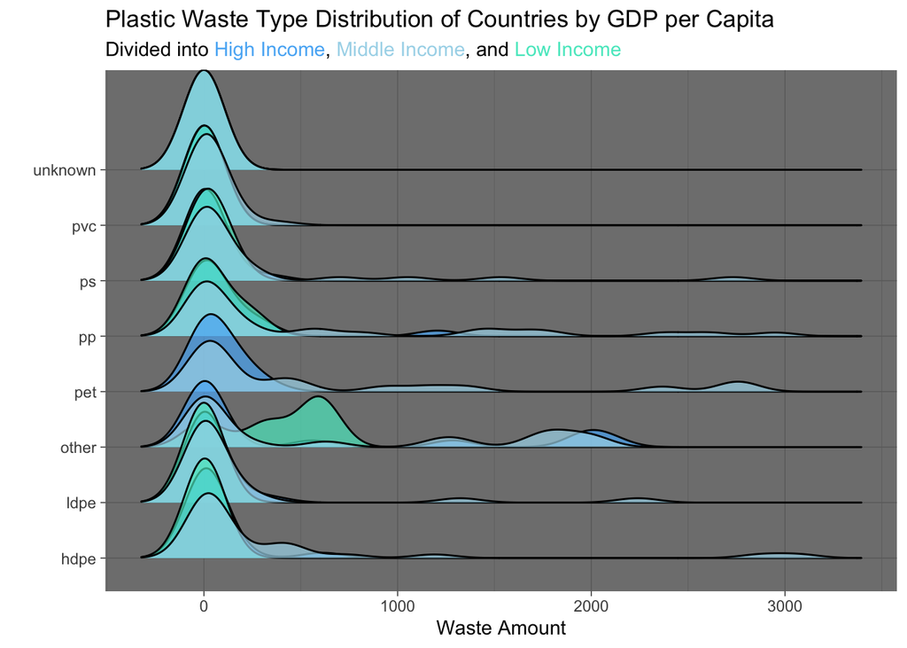

Figure 3: Ridge Plot Showing the Amount of Plastic Waste for Each Type of Plastic

```r
final_merged |>
  filter(year == 2019) |>
  group_by(country) |>
  summarize(unknown = sum(empty),
            hdpe = sum(hdpe),
            ldpe = sum(ldpe),
            other = sum(o),
            pet = sum(pet),
            pp = sum(pp),
            ps = sum(ps),
            pvc = sum(pvc),
            total = sum(total),
            gdp_per_capita = mean(gdp_per_capita),
            hdi = mean(HDI),
            .groups = "drop") |>
  mutate(income_group = case_when(
    gdp_per_capita < 1500 ~ "Low Income",
    gdp_per_capita > 12000 ~ "High Income",
    TRUE ~ "Middle Income")) |>
  pivot_longer(
    cols = unknown:pvc,
    names_to = "plastic_type",
    values_to = "waste") |>
  filter(waste <= 3500) |>

  ggplot(mapping = aes(x = waste,
                       y = plastic_type,
                       fill = income_group)) +
  geom_density_ridges(alpha = 0.7) +
  scale_fill_manual(values = c(
  "High Income"   = "#58b4f5",
  "Middle Income" = "#a8d8ea",
  "Low Income"    = "#56e8c8")) +
  labs(
    title = "Plastic Waste Type Distribution of Countries by GDP per Capita",
    subtitle = "Divided into <span style='color: #58b4f5;'>High Income</span>,
      <span style='color: #a8d8ea;'>Middle Income</span>,
    and <span style='color: #56e8c8;'>Low Income</span>",
    x = "Waste Amount",
    y = "",
    alt = "Density ridge plot showing the density of plastic waste audited
    for multiple types of plastic. Colored by GDP per capita category,
    High, Middle, and Low") +
  theme_dark() +
  theme(plot.subtitle =  element_markdown(),
        legend.position = "none")
```

The ridge plot shows how plastic waste amounts are distributed across income groups for each plastic type in 2019. Countries are grouped into low, middle, and high income based on GDP per capita thresholds. High income countries tend to have narrower distributions concentrated near zero, while middle income countries show wider spread, suggesting more variability in the scale of plastic collected per audit among that group. Similarly, low income countries show distributions close to lower waste amounts. This may reflect smaller audit events rather than less plastic pollution, as these countries may have less volunteer capacity to conduct large scale cleanups.

### Figure 2. Plastic Collected per Event vs. GDP by Region

Region is another factor that may play a role in plastic waste generation.

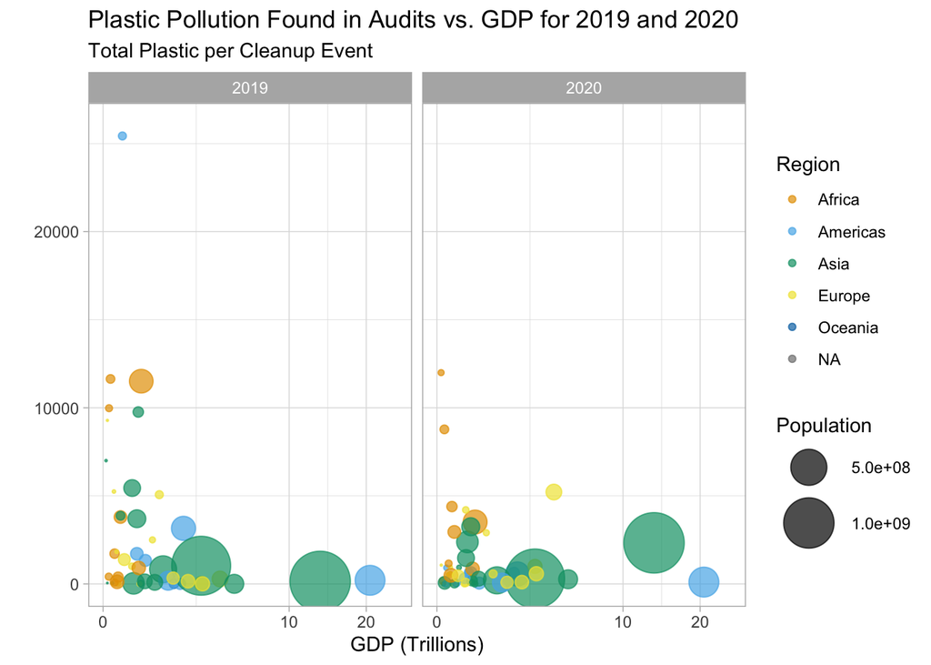

Figure 4: Bubble Plot of Plastic Pollution From Audits Against GDP for 2019 and 2020

```r
final_merged |>
  mutate(region = countrycode::countrycode(country,
            origin = "country.name",
            destination = "continent"),
         total_normalized = total / num_events,
         gdp_trillions = gdp / 1e6) |>
  filter_out(country == "EMPTY",
           total == 0,
           is.na(total),
           is.na(gdp_trillions),
           gdp_trillions == 0,
           is.na(region)) |>
  group_by(country, region, year) |>
  summarize(total_plastic = sum(total_normalized, na.rm = T),
            gdp_trillions = mean(gdp_trillions, na.rm = T),
            Population = mean(Population, na.rm = T)) |>
  ggplot(aes(x = gdp_trillions, y = total_plastic, size = Population,
             color = region)) +
    geom_point(alpha = 0.7) +
    scale_size(range = c(.1, 15), name ="Population") +
  labs(color = "Region",
       x = "GDP (Trillions)",
       title = "Plastic Pollution Found in Audits vs. GDP for 2019 and 2020",
       subtitle = "Total Plastic per Cleanup Event",
       y = "",
       alt = "Bubble chart showing plastic items found per cleanup event vs GDP in trillions,
       colored by region and sized by population") +
  coord_cartesian(ylim = c(0, 26000),
                  xlim = c(0,25)) +
  scale_color_discrete(na.translate = FALSE) +
  scale_x_sqrt() +
  facet_wrap(~ year) +
  theme_light() +
  scale_color_manual(values = c(
  "Africa"   = "#E69F00",
  "Americas" = "#56B4E9",
  "Asia"     = "#009E73",
  "Europe"   = "#F0E442",
  "Oceania"  = "#0072B2"
))
```

# Modeling What Predicts Plastic Collection

```r
library(tidyverse)
library(gt)
library(lme4)
library(lmerTest)
library(broom.mixed)
fit_final_maybe <- lmer(
  log_total_plastic ~
    log_population +
    log_pop_density +
    log_gdp_billions +
    year +
    region +
    (1 | country),
  data = model_df,
  REML = TRUE
)

tbl_final <- tidy(
  fit_final_maybe,
  effects = "fixed",
  conf.int = TRUE
) |>
  mutate(
    Predictor = dplyr::recode(
      term,
      `(Intercept)` = "Intercept",
      `log_population` = "Log Population",
      `log_pop_density` = "Log Population Density",
      `log_gdp_billions` = "Log GDP (billions)",
      `year2020` = "Year: 2020",
      .default = term
    ),
    Predictor = sub("^region", "Region: ", Predictor)
  ) |>
  select(
    Predictor,
    Estimate = estimate,
    `Std. Error` = std.error,
    `t value` = statistic,
    `p value` = p.value,
    `95% CI Lower` = conf.low,
    `95% CI Upper` = conf.high
  )

tbl_final |>
  gt() |>
  tab_header(
    title = md("**Final Linear Mixed Model Predicting Logged Plastic Collected**"),
    subtitle = "Response: log(total_plastic); random intercept for country"
  ) |>
  cols_label(
    Predictor = md("**Predictor**"),
    Estimate = md("**Estimate**"),
    `Std. Error` = md("**Std. Error**"),
    `t value` = md("**t value**"),
    `p value` = md("**p value**"),
    `95% CI Lower` = md("**95% CI Lower**"),
    `95% CI Upper` = md("**95% CI Upper**")
  ) |>
  fmt_number(
    columns = c(
      Estimate,
      `Std. Error`,
      `t value`,
      `95% CI Lower`,
      `95% CI Upper`
    ),
    decimals = 4
  ) |>
  fmt_number(
    columns = `p value`,
    decimals = 3
  ) |>
  tab_style(
    style = list(
      cell_text(weight = "bold")
    ),
    locations = cells_body(
      columns = `p value`,
      rows = Predictor == "Log Population"
    )
  ) |>
  tab_source_note(
    source_note = md(
      "Model includes region as a fixed effect and country as a random intercept. The response variable, population, population density, and GDP were log transformed."
    )
  )
```

**Final Linear Mixed Model Predicting Logged Plastic Collected**

Response: log(total_plastic); random intercept for country

| **Predictor** | **Estimate** | **Std. Error** | **t value** | **p value** | **95% CI Lower** | **95% CI Upper** |
| --- | --- | --- | --- | --- | --- | --- |
| Intercept | −0.3946 | 5.4459 | −0.0725 | 0.943 | −11.3816 | 10.5924 |
| Log Population | 0.9278 | 0.4084 | 2.2719 | 0.028 | 0.1056 | 1.7501 |
| Log Population Density | −0.3299 | 0.3526 | −0.9356 | 0.354 | −1.0384 | 0.3787 |
| Log GDP (billions) | −0.4573 | 0.3826 | −1.1954 | 0.238 | −1.2275 | 0.3129 |
| Year: 2020 | 0.2678 | 0.4132 | 0.6480 | 0.520 | −0.5644 | 1.1000 |
| Region: Eastern Africa | 2.2748 | 1.8253 | 1.2463 | 0.219 | −1.4073 | 5.9569 |
| Region: Eastern Asia | 0.9594 | 1.7741 | 0.5408 | 0.592 | −2.6224 | 4.5413 |
| Region: Eastern Europe | 1.0326 | 1.7242 | 0.5989 | 0.553 | −2.4513 | 4.5165 |
| Region: Middle Africa | 3.8144 | 2.7285 | 1.3980 | 0.167 | −1.6382 | 9.2670 |
| Region: Northern Africa | 0.8093 | 2.2916 | 0.3532 | 0.726 | −3.8507 | 5.4694 |
| Region: Northern America | 1.0748 | 2.3020 | 0.4669 | 0.643 | −3.5956 | 5.7451 |
| Region: Northern Europe | 1.9881 | 1.7277 | 1.1507 | 0.256 | −1.4920 | 5.4682 |
| Region: Oceania | −0.7332 | 2.8582 | −0.2565 | 0.799 | −6.5370 | 5.0707 |
| Region: South America | 2.0780 | 1.5783 | 1.3166 | 0.195 | −1.1035 | 5.2594 |
| Region: South-Eastern Asia | 3.4174 | 1.5303 | 2.2332 | 0.031 | 0.3276 | 6.5072 |
| Region: Southern Africa | 1.2806 | 2.3080 | 0.5549 | 0.583 | −3.4177 | 5.9789 |
| Region: Southern Asia | 1.6226 | 1.6587 | 0.9782 | 0.333 | −1.7119 | 4.9572 |
| Region: Southern Europe | 2.7508 | 1.5620 | 1.7610 | 0.085 | −0.4010 | 5.9026 |
| Region: Western Africa | 3.2466 | 1.6264 | 1.9962 | 0.052 | −0.0246 | 6.5178 |
| Region: Western Asia | −0.2045 | 1.6855 | −0.1213 | 0.904 | −3.5908 | 3.1819 |
| Region: Western Europe | 3.0972 | 1.7813 | 1.7387 | 0.090 | −0.5029 | 6.6972 |

Model includes region as a fixed effect and country as a random intercept. The response variable, population, population density, and GDP were log transformed.

```r
anova(fit_final_maybe) |>
  as.data.frame() |>
  tibble::rownames_to_column("Predictor") |>
  mutate(
    Predictor = dplyr::recode(
      Predictor,
      log_population = "Log Population",
      log_pop_density = "Log Population Density",
      log_gdp_billions = "Log GDP (billions)",
      year = "Year",
      region = "Region"
    )
  ) |>
  gt() |>
  tab_header(
    title = md("**Type III ANOVA for Final Mixed Model**"),
    subtitle = "Satterthwaite's method"
  ) |>
  fmt_number(
    columns = where(is.numeric),
    decimals = 3
  ) |>
  tab_style(
    style = list(
      cell_text(weight = "bold")
    ),
    locations = cells_body(
      rows = Predictor == "Log Population"
    )
  )
```

**Type III ANOVA for Final Mixed Model**

Satterthwaite's method

| Predictor | Sum Sq | Mean Sq | NumDF | DenDF | F value | Pr(>F) |
| --- | --- | --- | --- | --- | --- | --- |
| Log Population | 19.880 | 19.880 | 1.000 | 45.595 | 5.162 | 0.028 |
| Log Population Density | 3.371 | 3.371 | 1.000 | 49.054 | 0.875 | 0.354 |
| Log GDP (billions) | 5.503 | 5.503 | 1.000 | 45.780 | 1.429 | 0.238 |
| Year | 1.617 | 1.617 | 1.000 | 45.222 | 0.420 | 0.520 |
| Region | 72.355 | 4.522 | 16.000 | 37.798 | 1.174 | 0.331 |

A linear mixed effects model was fit to examine how demographic, economic, time, and regional factors relate to differences in plastic collected across countries and years. The response variable was log transformed total plastic collected. Population, population density, GDP, year, and region were included as fixed effects, while country was included as a random intercept to account for repeated observations within countries. The results show that log population was the only statistically significant predictor in the model, b = 0.928, SE = 0.408, t = 2.272, p = 0.028, with a 95% CI [0.106, 1.750]. This indicates that countries with larger populations tended to have higher levels of plastic collected, holding the other predictors constant. Log population density, log GDP, year, and the overall effect of region were not statistically significant. Central America was the reference region for the regional fixed effects. So, each regional coefficient represents the estimated difference in logged plastic collected between that region and Central America, holding the other predictors constant. Although some individual regional coefficients, such as South-Eastern Asia, had p-values below 0.05, the Type III ANOVA showed that region as a whole was not statistically significant, F(16, 37.798) = 1.174, p = 0.331. So, the final mixed model suggests that log population was the only signifigant predictor of logged plastic collected after accounting for country level differences rather than GDP, population density, year, or region.

#### Sources

Miller Recycling Corporation. (2026, January 13). Plastics recycling symbols explained. Miller Recycling. Miller Recycling